# NU-IT Research Computing Services: Regression Models with R - Day 3

By Diego Gomez-Zara

Today we will discuss methods for predictor variable selection. We often have a choice of many predictors and the goal is to select a small subset of them that provides a parsimonious yet well-fitting and powerful predictive model. A parsimonious model has fewer data requirements, reduced computational complexity, improved system representation, transparency, and insightfulness.

We will use two examples to illustrate the methods presented in this session.

```r
library(dplyr)
library(leaps)
library(car)
library(meifly)
```

We load the Healthcare insurace dataset as `health.data`.

```r
health.data <- read.csv("insurance.csv")
health.data$gender <- as.factor(health.data$gender)
health.data$gender <- relevel(health.data$gender, ref = "male")
health.data$smoker <- as.factor(health.data$smoker)
health.data$smoker <- relevel(health.data$smoker, ref = "no")
health.data$region <- as.factor(health.data$region)
health.data <- health.data %>% mutate_if(function(col) is.numeric(col) & !all(col == .$charges), scale)
```

We do the same for the Wine dataset as `wine.data`.

```r
wine.data <- read.csv("winequality-red.csv")
wine.data <- wine.data %>% mutate_if(function(col) is.numeric(col) & !all(col == .$quality), scale)
```

## Best Subset Selection

- **$R^2$ Criterion**: This criterion compares models based on their $R^2$ values, which are measures of the goodness of fit. Since $R^2$ can only increase by adding more variables to the model, it is trivially maximized by including all the available variables. In general, the $R^2$ criterion tends to produce models that are too large. Furthermore, although these models provide good fits, they do not necessarily give good predictions.
- **Adjusted $R^2$ Criterion**: This criterion is a modification of the previous one and incorporates a penalty for the number of variables included in the model. Thus, maximizing the adjusted $R^2$ takes into account reducing the mean squared error and the number of variables included in the model.
- **Akaike’s information criterion (AIC)**: Given a collection of models for the data, AIC estimates the quality of each model relative to each of the other models. It estimates the relative amount of *information lost* by a given model: the less information a model loses, the higher the quality of that model. Minimizing AIC is equivalent to maximizing the expected information in a model subject to a penalty term for the number of variables in the model. The formula $n\ln(SSE/n)+2(p+1)$, where $n$ is the number of observations, $SSE$ is the error sum of squares, and $p$ the number of predictors.

- The linear regression formula. We will use `charges ~ .`, where the dot represents all the other variables.
- The dataframe
- Searching method (`method`): `exhaustive` searches for all the models.
- Number of subsets of each size to return (`nbest`).

```r
regsubsets.out <- regsubsets(charges ~ ., health.data, method = "exhaustive", nbest=2)
```

We save the `summary()` of this object and print it as a table. We will get the variables that are included in the best of size `n`.

```r
summary.out <- summary(regsubsets.out)
as.data.frame(summary.out$outmat)
```

|  | age | genderfemale | bmi | children | smokeryes | regionnorthwest | regionsoutheast | regionsouthwest |
| --- | --- | --- | --- | --- | --- | --- | --- | --- |
| 1 ( 1 ) |  |  |  |  | * |  |  |  |
| 1 ( 2 ) | * |  |  |  |  |  |  |  |
| 2 ( 1 ) | * |  |  |  | * |  |  |  |
| 2 ( 2 ) |  |  | * |  | * |  |  |  |
| 3 ( 1 ) | * |  | * |  | * |  |  |  |
| 3 ( 2 ) | * |  |  | * | * |  |  |  |
| 4 ( 1 ) | * |  | * | * | * |  |  |  |
| 4 ( 2 ) | * |  | * |  | * |  | * |  |
| 5 ( 1 ) | * |  | * | * | * |  | * |  |
| 5 ( 2 ) | * |  | * | * | * |  |  | * |

[output cut: 5 more lines]

The package `leaps` provides a plot with the variables selected and their respective Adjusted $R^2$. Variables that have black boxes at the highest Y-axis value.

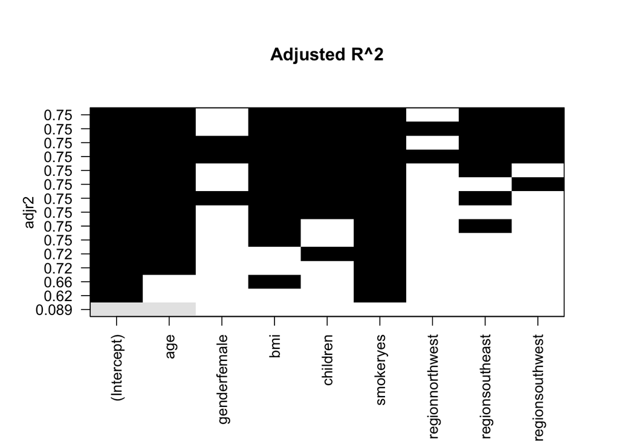

```r
plot(regsubsets.out, scale = "adjr2", main = "Adjusted R^2")
```

Another way of presenting the same information for adjusted $R^2$. The model with variables (counting dummy variables seprately) at the highest y-position has the highest adjusted $R^2$.

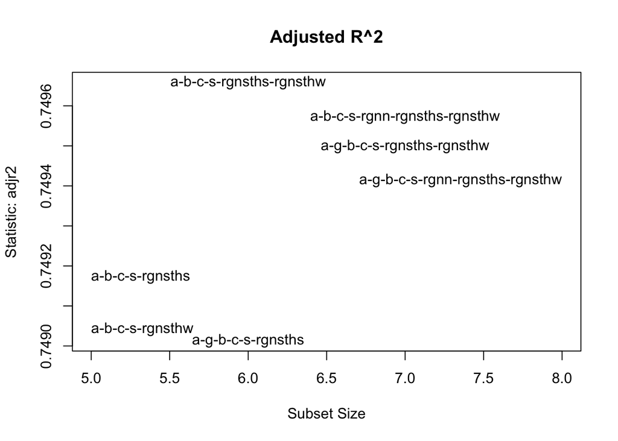

|  | Abbreviation |
| --- | --- |
| age | a |
| genderfemale | g |
| bmi | b |
| children | c |
| smokeryes | s |
| regionnorthwest | rgnn |
| regionsoutheast | rgnsths |
| regionsouthwest | rgnsthw |

```r
subsets(regsubsets.out, statistic="adjr2", legend = FALSE, min.size = 5, main = "Adjusted R^2")
```

We calculate the maximum $R^2$ of all these models.

```r
print(max(summary.out$adjr2))
```

```
## [1] 0.7496579
```

What is the model with the highest $R^2$?

```r
which.max(summary.out$adjr2)
```

```
## [1] 11
```

The model 11 has the highest $R^2$, and by calling `summary.out` we can identify the selected variables. The variables marked with `TRUE` are the chosen ones.

```r
summary.out$which[11,]
```

```
##     (Intercept)             age    genderfemale             bmi        children
##            TRUE            TRUE           FALSE            TRUE            TRUE
##       smokeryes regionnorthwest regionsoutheast regionsouthwest
##            TRUE           FALSE            TRUE            TRUE
```

We create the model according to these variables

```r
best.model <- lm(charges ~ age + bmi + children + smoker + region, health.data)
summary(best.model)
```

```
##
## Call:
## lm(formula = charges ~ age + bmi + children + smoker + region,
##     data = health.data)
##
## Residuals:
##      Min       1Q   Median       3Q      Max
## -11367.2  -2835.4   -979.7   1361.9  29935.5
##
## Coefficients:
##                 Estimate Std. Error t value Pr(>|t|)
## (Intercept)       8989.1      349.8  25.694  < 2e-16 ***
## age               3610.5      167.1  21.610  < 2e-16 ***
## bmi               2065.2      174.2  11.858  < 2e-16 ***
## children           572.1      166.0   3.445 0.000588 ***
## smokeryes        23836.3      411.9  57.875  < 2e-16 ***
## regionnorthwest   -352.2      476.1  -0.740 0.459618
## regionsoutheast  -1034.4      478.5  -2.162 0.030834 *
## regionsouthwest   -959.4      477.8  -2.008 0.044846 *
## ---
## Signif. codes:  0 '***' 0.001 '**' 0.01 '*' 0.05 '.' 0.1 ' ' 1
##
## Residual standard error: 6060 on 1330 degrees of freedom
## Multiple R-squared:  0.7509, Adjusted R-squared:  0.7496
## F-statistic: 572.7 on 7 and 1330 DF,  p-value: < 2.2e-16
```

### Exercise 1

Find the best model for the `wine.data` using the function `regsubsets()`. Assign the results to the variable `regsubsets.out.`

```r
regsubsets.out <- regsubsets(quality ~ ., wine.data, method = "exhaustive", nbest=2)
```

Assign the summary of the object `regsubsets.out` to the variable `summary.out`. Then, print as a dataframe the object `summary.out$outmat`.

```r
summary.out <- summary(regsubsets.out)
as.data.frame(summary.out$outmat)
```

|  | fixed_acidity | volatile_acidity | citric_acid | residual_sugar | chlorides | free_sulfur_dioxide | total_sulfur_dioxide | density | pH | sulphates | alcohol |
| --- | --- | --- | --- | --- | --- | --- | --- | --- | --- | --- | --- |
| 1 ( 1 ) |  |  |  |  |  |  |  |  |  |  | * |
| 1 ( 2 ) |  | * |  |  |  |  |  |  |  |  |  |
| 2 ( 1 ) |  | * |  |  |  |  |  |  |  |  | * |
| 2 ( 2 ) |  |  |  |  |  |  |  |  |  | * | * |
| 3 ( 1 ) |  | * |  |  |  |  |  |  |  | * | * |
| 3 ( 2 ) |  | * |  |  |  |  | * |  |  |  | * |
| 4 ( 1 ) |  | * |  |  |  |  | * |  |  | * | * |
| 4 ( 2 ) |  | * |  |  | * |  |  |  |  | * | * |
| 5 ( 1 ) |  | * |  |  | * |  | * |  |  | * | * |
| 5 ( 2 ) |  | * |  |  | * |  |  |  | * | * | * |

[output cut: 6 more lines]

Plot the Adjusted $R^2$ from `regsubsets.out` using `scale = "adjr2`.

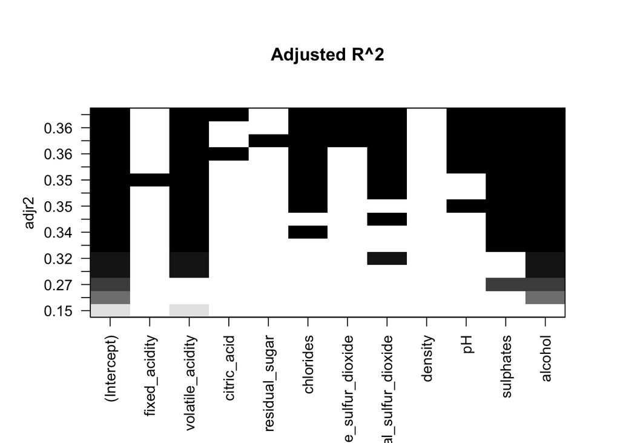

```r
plot(regsubsets.out, scale = "adjr2", main = "Adjusted R^2")
```

Identify the model with the hightest adj $R^2$. You can use the function `which.max()` on `summary.out$adjr2`

```r
which.max(summary.out$adjr2)
```

```
## [1] 15
```

Identify the selected predictors of the model with the highest $R^2$ using the command `summary.out$which`.

```r
summary.out$which[15,]
```

```
##          (Intercept)        fixed_acidity     volatile_acidity
##                 TRUE                FALSE                 TRUE
##          citric_acid       residual_sugar            chlorides
##                 TRUE                FALSE                 TRUE
##  free_sulfur_dioxide total_sulfur_dioxide              density
##                 TRUE                 TRUE                FALSE
##                   pH            sulphates              alcohol
##                 TRUE                 TRUE                 TRUE
```

Create the linear regression model `wine.best.model` using the function `lm()` with the best subset found. Then, print the results using `summary()`.

```r
wine.best.model <- lm(quality ~ volatile_acidity + citric_acid + chlorides + free_sulfur_dioxide + total_sulfur_dioxide + pH + sulphates + alcohol, wine.data)
summary(wine.best.model)
```

```
##
## Call:
## lm(formula = quality ~ volatile_acidity + citric_acid + chlorides +
##     free_sulfur_dioxide + total_sulfur_dioxide + pH + sulphates +
##     alcohol, data = wine.data)
##
## Residuals:
##      Min       1Q   Median       3Q      Max
## -2.66890 -0.37044 -0.04474  0.45697  2.02363
##
## Coefficients:
##                      Estimate Std. Error t value Pr(>|t|)
## (Intercept)           5.63602    0.01620 347.946  < 2e-16 ***
## volatile_acidity     -0.19224    0.02076  -9.260  < 2e-16 ***
## citric_acid          -0.02524    0.02372  -1.064   0.2876
## chlorides            -0.09175    0.01895  -4.841 1.42e-06 ***
## free_sulfur_dioxide   0.04979    0.02245   2.218   0.0267 *
## total_sulfur_dioxide -0.11072    0.02288  -4.840 1.42e-06 ***
## pH                   -0.08478    0.02055  -4.125 3.90e-05 ***
## sulphates             0.15110    0.01868   8.088 1.19e-15 ***
## alcohol               0.31211    0.01825  17.099  < 2e-16 ***
## ---
## Signif. codes:  0 '***' 0.001 '**' 0.01 '*' 0.05 '.' 0.1 ' ' 1
##
## Residual standard error: 0.6477 on 1590 degrees of freedom
## Multiple R-squared:  0.3599, Adjusted R-squared:  0.3567
## F-statistic: 111.8 on 8 and 1590 DF,  p-value: < 2.2e-16
```

### Using the package `meifly`

- y: the dependent variable
- x: the predictors dataset
- method: the method used to fit the model. In this case `lm`

We create all the possible models with $p$ predictors. In the `health.data`, we have 6 predictors. Therefore, there can be $2^6-1=63$ possible models to build.

```r
fitall.out <- fitall(y = health.data$charges,
                     x = health.data[,c("age","gender","bmi","children","smoker","region")],
                     method="lm")
```

```
## Fitting 63 models...
```

The variable `fitall.out` is a list of the 63 possible linear regression models. We can use the function `summary()` to have the metrics of each model.

```r
summary.fitall.out <- summary(fitall.out)
summary.fitall.out
```

|  | df | logL | AIC | BIC | R2 | adjR2 | n | model |
| --- | --- | --- | --- | --- | --- | --- | --- | --- |
| m1 | 3 | -14414.97 | -28835.95 | -28851.55 | 0.089405900 | 0.088724317 | 1338 | 1 |
| m2 | 3 | -14475.43 | -28956.86 | -28972.46 | 0.003282380 | 0.002536334 | 1338 | 2 |
| m3 | 4 | -14412.00 | -28832.00 | -28852.80 | 0.093443480 | 0.092085343 | 1338 | 3 |
| m4 | 3 | -14450.78 | -28907.56 | -28923.16 | 0.039339140 | 0.038620082 | 1338 | 4 |
| m5 | 4 | -14394.25 | -28796.50 | -28817.29 | 0.117183386 | 0.115860814 | 1338 | 5 |
| m6 | 4 | -14449.17 | -28906.33 | -28927.13 | 0.041657231 | 0.040221511 | 1338 | 6 |
| m7 | 5 | -14391.91 | -28793.83 | -28819.82 | 0.120258034 | 0.118279604 | 1338 | 7 |
| m8 | 3 | -14474.53 | -28955.06 | -28970.66 | 0.004623759 | 0.003878717 | 1338 | 8 |
| m9 | 4 | -14412.72 | -28833.44 | -28854.24 | 0.092469476 | 0.091109880 | 1338 | 9 |
| m10 | 4 | -14472.41 | -28952.82 | -28973.62 | 0.007774704 | 0.006288224 | 1338 | 10 |

[output cut: 53 more lines]

We use the function `which.max()` to identify the model with the maximum Adj. $R^2$ possible.

```r
which.max(summary.fitall.out$adjR2)
```

```
## [1] 61
```

The model 61 has the highest adjusted $R^2$: 0.7496. We can get the model by calling the element 61 of the object ``fitall.out`.

```r
fitall.out[61]
```

```
## $`61`
##
## Call:
## lm(formula = y ~ age + bmi + children + smoker + region, data = data,
##     model = FALSE)
##
## Coefficients:
##     (Intercept)              age              bmi         children
##          8989.1           3610.5           2065.2            572.1
##       smokeryes  regionnorthwest  regionsoutheast  regionsouthwest
##         23836.3           -352.2          -1034.4           -959.4
##
##
## attr(,"class")
## [1] "ensemble"
```

This will return the object `lm()`. We can see the results using the function `summary()`

```r
summary(fitall.out[[61]])
```

```
##
## Call:
## lm(formula = y ~ age + bmi + children + smoker + region, data = data,
##     model = FALSE)
##
## Residuals:
##      Min       1Q   Median       3Q      Max
## -11367.2  -2835.4   -979.7   1361.9  29935.5
##
## Coefficients:
##                 Estimate Std. Error t value Pr(>|t|)
## (Intercept)       8989.1      349.8  25.694  < 2e-16 ***
## age               3610.5      167.1  21.610  < 2e-16 ***
## bmi               2065.2      174.2  11.858  < 2e-16 ***
## children           572.1      166.0   3.445 0.000588 ***
## smokeryes        23836.3      411.9  57.875  < 2e-16 ***
## regionnorthwest   -352.2      476.1  -0.740 0.459618
## regionsoutheast  -1034.4      478.5  -2.162 0.030834 *
## regionsouthwest   -959.4      477.8  -2.008 0.044846 *
## ---
## Signif. codes:  0 '***' 0.001 '**' 0.01 '*' 0.05 '.' 0.1 ' ' 1
##
## Residual standard error: 6060 on 1330 degrees of freedom
## Multiple R-squared:  0.7509, Adjusted R-squared:  0.7496
## F-statistic: 572.7 on 7 and 1330 DF,  p-value: < 2.2e-16
```

## Exercise 2

Create the best model possible using `fitall()`. The `wine.data` has 11 predictors, and we can get $2^11-1=2047$ models. Assign the results to the variable `fitall.out()`.

```r
fitall.out <- fitall(y = wine.data$quality,
                     x = wine.data[,c("fixed_acidity", "volatile_acidity", "citric_acid", "residual_sugar",
                                      "chlorides","free_sulfur_dioxide","total_sulfur_dioxide","density",
                                      "pH","sulphates","alcohol")],
                     method="lm")
```

```
## Fitting 2047 models...
```

Use the function `summary()` to have all models’ metrics.

```r
summary.fitall.out <- summary(fitall.out)
summary.fitall.out
```

|  | df | logL | AIC | BIC | R2 | adjR2 | n | model |
| --- | --- | --- | --- | --- | --- | --- | --- | --- |
| m1 | 3 | -1914.235 | -3834.471 | -3850.602 | 0.0153888116 | 0.0147722736 | 1599 | 1 |
| m2 | 3 | -1794.312 | -3594.624 | -3610.756 | 0.1525353797 | 0.1520047193 | 1599 | 2 |
| m3 | 4 | -1793.729 | -3595.459 | -3616.968 | 0.1531527315 | 0.1520915194 | 1599 | 3 |
| m4 | 3 | -1884.577 | -3775.155 | -3791.286 | 0.0512445152 | 0.0506504291 | 1599 | 4 |
| m5 | 4 | -1883.372 | -3774.745 | -3796.253 | 0.0526734108 | 0.0514862848 | 1599 | 5 |
| m6 | 4 | -1794.160 | -3596.320 | -3617.828 | 0.1526968336 | 0.1516350502 | 1599 | 6 |
| m7 | 5 | -1793.707 | -3597.415 | -3624.300 | 0.1531761470 | 0.1515833748 | 1599 | 7 |
| m8 | 3 | -1926.484 | -3858.967 | -3875.098 | 0.0001885579 | -0.0004374981 | 1599 | 8 |
| m9 | 4 | -1914.235 | -3836.470 | -3857.979 | 0.0153890717 | 0.0141552234 | 1599 | 9 |
| m10 | 4 | -1794.114 | -3596.229 | -3617.737 | 0.1527450706 | 0.1516833477 | 1599 | 10 |

[output cut: 2037 more lines]

Use the function `which.max()` to identify the model with the maximum Adj. $R^2$ possible.

```r
which.max(summary.fitall.out$adjR2)
```

```
## [1] 1910
```

Get the identified model with the highest adjusted $R^2$. You can get the element by indexing the object `fitall.out`.

```r
fitall.out[[1910]]
```

```
##
## Call:
## lm(formula = y ~ volatile_acidity + citric_acid + chlorides +
##     free_sulfur_dioxide + total_sulfur_dioxide + pH + sulphates +
##     alcohol, data = data, model = FALSE)
##
## Coefficients:
##          (Intercept)      volatile_acidity           citric_acid
##              5.63602              -0.19224              -0.02524
##            chlorides   free_sulfur_dioxide  total_sulfur_dioxide
##             -0.09175               0.04979              -0.11072
##                   pH             sulphates               alcohol
##             -0.08478               0.15110               0.31211
```

This will return the object `lm()`. We can see the results using the function `summary()`

```r
summary(fitall.out[[1910]])
```

```
##
## Call:
## lm(formula = y ~ volatile_acidity + citric_acid + chlorides +
##     free_sulfur_dioxide + total_sulfur_dioxide + pH + sulphates +
##     alcohol, data = data, model = FALSE)
##
## Residuals:
##      Min       1Q   Median       3Q      Max
## -2.66890 -0.37044 -0.04474  0.45697  2.02363
##
## Coefficients:
##                      Estimate Std. Error t value Pr(>|t|)
## (Intercept)           5.63602    0.01620 347.946  < 2e-16 ***
## volatile_acidity     -0.19224    0.02076  -9.260  < 2e-16 ***
## citric_acid          -0.02524    0.02372  -1.064   0.2876
## chlorides            -0.09175    0.01895  -4.841 1.42e-06 ***
## free_sulfur_dioxide   0.04979    0.02245   2.218   0.0267 *
## total_sulfur_dioxide -0.11072    0.02288  -4.840 1.42e-06 ***
## pH                   -0.08478    0.02055  -4.125 3.90e-05 ***
## sulphates             0.15110    0.01868   8.088 1.19e-15 ***
## alcohol               0.31211    0.01825  17.099  < 2e-16 ***
## ---
## Signif. codes:  0 '***' 0.001 '**' 0.01 '*' 0.05 '.' 0.1 ' ' 1
##
## Residual standard error: 0.6477 on 1590 degrees of freedom
## Multiple R-squared:  0.3599, Adjusted R-squared:  0.3567
## F-statistic: 111.8 on 8 and 1590 DF,  p-value: < 2.2e-16
```

## Stepwise Regression

This technique selects a single model by entering or removing predictors in a stepwise manner (i.e., one at a time) according to a set of rules. Stepwise regression does not evaluate all models and does not optimize some well-defined criterion of which model is better, as does the best subset selection method. There are two basic versions of stepwise regression:

- **Forward**: This version starts from the null model and enters variables one at a time. It proceeds only in one direction with no option of removing the previously entered variables.
- **Backward**: This version starts from the full model and removes variables one at a time. It proceeds only in one direction with no option of entering the previously removed variables.

The `lm.step()` function in R uses the AIC criterion. The criteria here is *the lower the better*.

We start with backward stepwise selection. This method will drop variables until the AIC can not be minimized more. The final model is the one selected by this technique. We use the function `step()` to run this procedure. The parameters are:

- The linear model. We will use the full model here (`lm(log(charges) ~ ., health.data)`).
- Direction: The mode of stepwise search. It can be either `backward` or `forward`.

Now, we will create the object `backward.selection` to perform this process.

```r
backward.selection <- step(lm(log(charges) ~ ., health.data), direction="backward")
```

```
## Start:  AIC=-2162.05
## log(charges) ~ age + gender + bmi + children + smoker + region
##
##            Df Sum of Sq    RSS      AIC
## <none>                  262.33 -2162.05
## - gender    1      1.89 264.21 -2154.46
## - region    3      4.68 267.01 -2144.38
## - bmi       1      8.04 270.37 -2123.67
## - children  1     20.08 282.41 -2065.37
## - age       1    310.40 572.73 -1119.31
## - smoker    1    520.12 782.45  -701.83
```

No variables were removed. The full model has $AIC=-2162.05$ and the model without the variable `gender` has $AIC=-2154.46$ The lower the better ($-2162.05 < -2154.46$), so the method selects the full model as the best.

We will try now the **forward stepwise selection**. Here, we start with the null model and start adding variables until finding the lowest *AIC*. We create a null model `min.model` using only the intercept (`lm(log(charges) ~ 1, health.data)`). We need to give a reference to the method, so we add the formula of the full moder in paramater `scope`.

```r
min.model <- lm(log(charges) ~ 1, health.data)
forward.selection <- step(min.model, direction="forward", scope = ~ age + gender + bmi + children + smoker + region)
```

```
## Start:  AIC=-223.51
## log(charges) ~ 1
##
##            Df Sum of Sq     RSS      AIC
## + smoker    1    500.68  629.79 -1004.24
## + age       1    314.96  815.51  -658.46
## + children  1     29.43 1101.05  -256.79
## + bmi       1     19.90 1110.58  -245.27
## <none>                  1130.47  -223.51
## + region    3      3.55 1126.92  -221.72
## + gender    1      0.04 1130.44  -221.55
##
## Step:  AIC=-1004.24
## log(charges) ~ smoker
##
##            Df Sum of Sq    RSS     AIC
## + age       1    335.35 294.44 -2019.6
## + children  1     27.59 602.20 -1062.2
## + bmi       1     19.16 610.63 -1043.6
## + gender    1      2.31 627.48 -1007.2
## <none>                  629.79 -1004.2
## + region    3      2.48 627.31 -1003.5
##
## Step:  AIC=-2019.56
## log(charges) ~ smoker + age
##
##            Df Sum of Sq    RSS     AIC
## + children  1   20.0307 274.40 -2111.8
## + bmi       1    5.7011 288.74 -2043.7
## + region    3    2.3132 292.12 -2024.1
## + gender    1    1.3732 293.06 -2023.8
## <none>                  294.44 -2019.6
##
## Step:  AIC=-2111.83
## log(charges) ~ smoker + age + children
##
##          Df Sum of Sq    RSS     AIC
## + bmi     1    5.5293 268.88 -2137.1
## + region  3    2.4973 271.91 -2118.1
## + gender  1    1.5629 272.84 -2117.5
## <none>                274.40 -2111.8
##
## Step:  AIC=-2137.06
## log(charges) ~ smoker + age + children + bmi
##
##          Df Sum of Sq    RSS     AIC
## + region  3    4.6613 264.21 -2154.5
## + gender  1    1.8652 267.01 -2144.4
## <none>                268.88 -2137.1
##
## Step:  AIC=-2154.46
## log(charges) ~ smoker + age + children + bmi + region
##
##          Df Sum of Sq    RSS     AIC
## + gender  1    1.8855 262.33 -2162.1
## <none>                264.21 -2154.5
##
## Step:  AIC=-2162.05
## log(charges) ~ smoker + age + children + bmi + region + gender
```

```r
forward.selection
```

```
##
## Call:
## lm(formula = log(charges) ~ smoker + age + children + bmi + region +
##     gender, data = health.data)
##
## Coefficients:
##     (Intercept)        smokeryes              age         children
##         8.83263          1.55432          0.48587          0.12279
##             bmi  regionnorthwest  regionsoutheast  regionsouthwest
##         0.08156         -0.06379         -0.15720         -0.12895
##    genderfemale
##         0.07542
```

As well as backward stepwise selection, this method selects the full model as the best one.

### Exercise 3

Run backward and forward stepwise selection for `wine.data` and its regression models.

Create here the backward step and assign it to `backward.selection`, which is model the best found?

```r
backward.selection <- step(lm(log(quality) ~ ., wine.data), direction="backward")
```

```
## Start:  AIC=-6808.37
## log(quality) ~ fixed_acidity + volatile_acidity + citric_acid +
##     residual_sugar + chlorides + free_sulfur_dioxide + total_sulfur_dioxide +
##     density + pH + sulphates + alcohol
##
##                        Df Sum of Sq    RSS     AIC
## - density               1   0.00053 22.293 -6810.3
## - fixed_acidity         1   0.00325 22.295 -6810.1
## - residual_sugar        1   0.00378 22.296 -6810.1
## <none>                              22.292 -6808.4
## - citric_acid           1   0.03781 22.330 -6807.7
## - free_sulfur_dioxide   1   0.06001 22.352 -6806.1
## - pH                    1   0.09070 22.383 -6803.9
## - total_sulfur_dioxide  1   0.22506 22.517 -6794.3
## - chlorides             1   0.26839 22.561 -6791.2
## - sulphates             1   0.78237 23.075 -6755.2
## - volatile_acidity      1   1.30451 23.597 -6719.4
## - alcohol               1   1.44867 23.741 -6709.7
##
## Step:  AIC=-6810.33
## log(quality) ~ fixed_acidity + volatile_acidity + citric_acid +
##     residual_sugar + chlorides + free_sulfur_dioxide + total_sulfur_dioxide +
##     pH + sulphates + alcohol
##
##                        Df Sum of Sq    RSS     AIC
## - residual_sugar        1    0.0035 22.296 -6812.1
## - fixed_acidity         1    0.0039 22.297 -6812.0
## <none>                              22.293 -6810.3
## - citric_acid           1    0.0379 22.331 -6809.6
## - free_sulfur_dioxide   1    0.0614 22.354 -6807.9
## - pH                    1    0.1469 22.440 -6801.8
## - total_sulfur_dioxide  1    0.2282 22.521 -6796.0
## - chlorides             1    0.2730 22.566 -6792.9
## - sulphates             1    0.8229 23.116 -6754.4
## - volatile_acidity      1    1.3333 23.626 -6719.4
## - alcohol               1    3.4775 25.770 -6580.5
##
## Step:  AIC=-6812.07
## log(quality) ~ fixed_acidity + volatile_acidity + citric_acid +
##     chlorides + free_sulfur_dioxide + total_sulfur_dioxide +
```

[output cut: 13 more lines]

```
##
## Step:  AIC=-6813.75
## log(quality) ~ volatile_acidity + citric_acid + chlorides + free_sulfur_dioxide +
##     total_sulfur_dioxide + pH + sulphates + alcohol
##
##                        Df Sum of Sq    RSS     AIC
## <none>                              22.301 -6813.7
## - citric_acid           1    0.0341 22.335 -6813.3
## - free_sulfur_dioxide   1    0.0679 22.369 -6810.9
## - pH                    1    0.2431 22.544 -6798.4
## - total_sulfur_dioxide  1    0.2613 22.562 -6797.1
## - chlorides             1    0.3089 22.610 -6793.8
## - sulphates             1    0.8312 23.132 -6757.2
## - volatile_acidity      1    1.3784 23.679 -6719.8
## - alcohol               1    3.5538 25.855 -6579.3
```

Now, create the forward stepwise selector. Remember to update the dataframe, the formula, and the dependent variable (`quality`).

```r
min.model <- lm(log(quality) ~ 1, wine.data)
forward.selection <- step(min.model, direction="forward", scope = ~ fixed_acidity + volatile_acidity + citric_acid + residual_sugar + chlorides + free_sulfur_dioxide + total_sulfur_dioxide + density + pH + sulphates + alcohol)
```

```
## Start:  AIC=-6162.35
## log(quality) ~ 1
##
##                        Df Sum of Sq    RSS     AIC
## + alcohol               1    6.9438 26.909 -6527.4
## + volatile_acidity      1    5.3110 28.541 -6433.2
## + sulphates             1    2.0370 31.815 -6259.6
## + citric_acid           1    1.6427 32.210 -6239.9
## + total_sulfur_dioxide  1    0.9725 32.880 -6207.0
## + density               1    0.9248 32.927 -6204.6
## + chlorides             1    0.5524 33.300 -6186.7
## + fixed_acidity         1    0.4853 33.367 -6183.4
## + pH                    1    0.1272 33.725 -6166.4
## + free_sulfur_dioxide   1    0.0526 33.800 -6162.8
## <none>                              33.852 -6162.3
## + residual_sugar        1    0.0028 33.849 -6160.5
##
## Step:  AIC=-6527.42
## log(quality) ~ alcohol
##
##                        Df Sum of Sq    RSS     AIC
## + volatile_acidity      1    3.2721 23.636 -6732.7
## + sulphates             1    1.4061 25.502 -6611.2
## + citric_acid           1    0.9962 25.912 -6585.7
## + pH                    1    0.8431 26.065 -6576.3
## + fixed_acidity         1    0.7410 26.168 -6570.1
## + total_sulfur_dioxide  1    0.2061 26.703 -6537.7
## + density               1    0.1586 26.750 -6534.9
## <none>                              26.909 -6527.4
## + chlorides             1    0.0271 26.881 -6527.0
## + residual_sugar        1    0.0033 26.905 -6525.6
## + free_sulfur_dioxide   1    0.0022 26.906 -6525.5
##
## Step:  AIC=-6732.74
## log(quality) ~ alcohol + volatile_acidity
##
##                        Df Sum of Sq    RSS     AIC
## + sulphates             1   0.57844 23.058 -6770.4
## + pH                    1   0.17128 23.465 -6742.4
## + total_sulfur_dioxide  1   0.15084 23.486 -6741.0
```

[output cut: 65 more lines]

```
## + citric_acid     1  0.034103 22.301 -6813.7
## <none>                        22.335 -6813.3
## + fixed_acidity   1  0.002221 22.333 -6811.5
## + residual_sugar  1  0.001487 22.333 -6811.4
## + density         1  0.001101 22.334 -6811.4
##
## Step:  AIC=-6813.75
## log(quality) ~ alcohol + volatile_acidity + sulphates + chlorides +
##     total_sulfur_dioxide + pH + free_sulfur_dioxide + citric_acid
##
##                  Df Sum of Sq    RSS     AIC
## <none>                        22.301 -6813.7
## + fixed_acidity   1 0.0045312 22.296 -6812.1
## + residual_sugar  1 0.0041271 22.297 -6812.0
## + density         1 0.0036749 22.297 -6812.0
```

```r
forward.selection
```

```
##
## Call:
## lm(formula = log(quality) ~ alcohol + volatile_acidity + sulphates +
##     chlorides + total_sulfur_dioxide + pH + free_sulfur_dioxide +
##     citric_acid, data = wine.data)
##
## Coefficients:
##          (Intercept)               alcohol      volatile_acidity
##             1.718759              0.053124             -0.037629
##            sulphates             chlorides  total_sulfur_dioxide
##             0.026295             -0.016263             -0.018055
##                   pH   free_sulfur_dioxide           citric_acid
##            -0.015647              0.009032             -0.006763
```

Compare the models and see if they are the same:

```r
backward.selection$call
```

```
## lm(formula = log(quality) ~ volatile_acidity + citric_acid +
##     chlorides + free_sulfur_dioxide + total_sulfur_dioxide +
##     pH + sulphates + alcohol, data = wine.data)
```

```r
forward.selection$call
```

```
## lm(formula = log(quality) ~ alcohol + volatile_acidity + sulphates +
##     chlorides + total_sulfur_dioxide + pH + free_sulfur_dioxide +
##     citric_acid, data = wine.data)
```

## More resources

- [Tamhane, A. C. (2020). Predictive Analytics: Parametric Models for Regression and Classification Using R. John Wiley & Sons.](https://onlinelibrary-wiley-com.turing.library.northwestern.edu/doi/book/10.1002/9781119464761)
- [All subset regression with leaps, bestglm, glmulti, and meifly](https://rstudio-pubs-static.s3.amazonaws.com/2897_9220b21cfc0c43a396ff9abf122bb351.html)
- [Stepwise Regression Essentials in R](http://www.sthda.com/english/articles/37-model-selection-essentials-in-r/154-stepwise-regression-essentials-in-r/)